# SUF Ledelsesmøde

Juni, 2017

## En hurtig refresher

## Hvad var problemet?

- SUF Hovedstadens økonomi fungerer dårligt af flere årsager
- Man har overdrevet indberetninger af medlemstal for at dække udgifterne
- Københavns kommune har ændret bevillingssystem
- Økonomistyringen har været generelt dårlig
  - (+) diverse administrative problemer

## Siden sidst

- AM16
  - Et års husleje og hjælp til at betale gæld
- Vi har knoklet … de fedeste ting kommer her

## En nem måde at dokumentere aktivitet

[figure not shown]

## En masse fodarbejde til fremtiden

[figure not shown]

## Et (næsten) ægte medlemsskab

[figure not shown]

## Et overblik over vores medlemmer

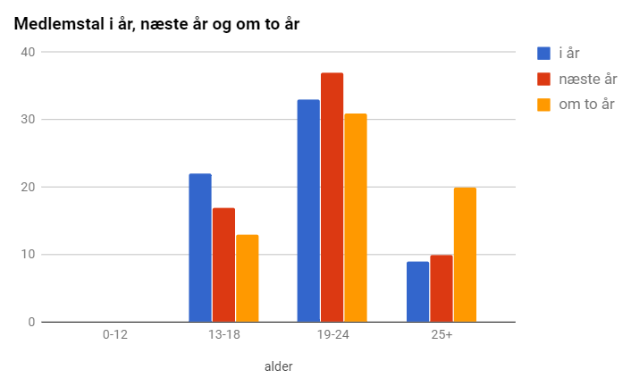

## En fungerende husgruppe

[figure not shown]

## Siden sidst

- Vi har også lavet en masse kedelige ting
  - SKAT har fået deres penge
  - Vi har fixet gamle problemer med løn mm.
  - Vi har 'overslagsbogført'
- men vi har **IKKE** søgt kommunestøtte for næste år

## Hvad!?

## Hvad!?

- **Hvorfor?**
  - Det står i jeres bilag
- **Hvordan ser fremtiden så ud?**
  - Fattig
  - Og helt sikkert anderledes end det SUF Hovedstaden vi kender
  - Bilaget outliner 3 scenarier for den nærmeste fremtid.
  - Vi vil gerne have en snak, både om den nærmeste fremtid og det der ligger længere forude.

## Hvorfor ikke søge?

- Kommunens system har et 2-årigt overlap. Hvis man vil være 'legit' skal man altså undlade at søge i mindst 2 år
- 'Nedtrapning' vil tage alt for mange år
- Der kan ikke samles et 'hold' der ville være villige til at skrive under.

## Fremtiden

## Den nærmeste fremtid

- Der er en risiko for at Hovedstaden får nogle store udgifter i processen. Nogle af dem dækkes af en aftale indgået med sidste ledelse. Andre er uafklarede.
- Hovedstaden har i sagens natur ikke ret mange penge.
- Hvordan man handler lige nu, skal spille sammen med hvordan man regner med at fremtiden ser ud.

## Det længere sigt

- Hovedstaden kan ikke løbe rundt med de penge kommunen retmæssigt kan give til os.
  - Hvis det ikke kan løbe rundt på lang sigt, kan vi lige så godt lukke med det samme
- Vi kan få 30-80.000 kr i støtte af kommunen
  - Det er et bredt interval
  - Som er strengt mindre end huslejen
  - Det er nærliggende at landsorganisationen er en del af løsningen

## Tak!

Tak for jeres tid! - nu skal vi snakke sammen.

## Hvad skal vi snakke om

- Vil nationalt betale et eventuelt tilbagebetalingskrav?
- Hvordan dækker vi huslejen i 2019?
- Hvordan dækker vi huslejen efter 2019?